# Latest Iteration of HOTR model evaluation

Michelle M. Fink

03/03/2020

Expand code block to see libraries and functions used.

```r
library(dplyr)
library(data.table)
library(stringr)
library(randomForest)
library(lme4)
library(ROCR)
library(PresenceAbsence) # for Kappa and PCC
library(ggplot2)

getConfusionMatrix <- function(tbl) {
  #https://stats.stackexchange.com/questions/35609/why-do-i-need-bag-composition-to-calculate-oob-error-of-combined-random-forest-m/35613#35613
  class.error = vector()

  for (i in 1:nrow(tbl)) {
    rowSum = sum(tbl[i,])
    accurate = diag(tbl)[i]
    error = rowSum - accurate

    class.error[i] = error / rowSum
  }
  return(cbind(tbl, class.error))
}

opt.cut <- function(perf, pred){
  #https://www.r-bloggers.com/a-small-introduction-to-the-rocr-package/
  #calculates sensitivity = specificity threshold
  mapply(FUN=function(x, y, p){
    d = (x - 0)^2 + (y-1)^2
    ind = which(d == min(d))
    c(sensitivity = y[[ind]], specificity = 1-x[[ind]],
      cutoff = p[[ind]])
  }, perf@x.values, perf@y.values, pred@cutoffs)
}

modEval <- function(modobj, run_name, modtype='GLM'){
  if(modtype=="RF"){
    p_rf.mod <- predict(modobj, type = "prob")
    pred.mod <- prediction(p_rf.mod[,2], modobj$y)
  } else {
    pred.mod <- prediction(modobj@resp$mu, modobj@resp$y)
  }

  perf.roc <- performance(pred.mod, "tpr", "fpr")
  perf.err <- performance(pred.mod, "err")
  AUC <- performance(pred.mod, measure = "auc")@y.values[[1]]
  sst <- opt.cut(perf.roc,pred.mod)
  TSS <- sst[1] + sst[2] - 1

  if(modtype=="RF"){
    ptab_rf.mod <- table(modobj$predicted, modobj$y)
    err_rate <- 1-sum(diag(ptab_rf.mod))/sum(ptab_rf.mod)
  } else {
    err_rate <- perf.err@y.values[[1]][which(perf.err@x.values[[1]] == sst[3])]
  }

  #Presence.Absence insists on its own data structure
  padat <- data.frame(ID=seq(1:length(pred.mod@predictions[[1]])),
                    OBS=as.numeric(levels(pred.mod@labels[[1]]))[pred.mod@labels[[1]]],
                    PRED=pred.mod@predictions[[1]])

  pacmx <- cmx(padat, threshold = sst[3])
  kappa <- Kappa(pacmx, st.dev = FALSE)
  PCC <- pcc(pacmx, st.dev = FALSE)

  #plotting ROC
  #ggplot code adapted from https://davidrroberts.wordpress.com/2015/09/22/quick-auc-function-in-r-with-rocr-package/
  i <- which(perf.roc@alpha.values[[1]] == sst[3])
  plotdat <- data.frame(FP=perf.roc@x.values[[1]],TP=perf.roc@y.values[[1]])
  rocp <- ggplot(plotdat, aes(x=FP,y=TP)) +
    geom_line(lwd=2, col="red") +
    geom_abline(intercept=0,slope=1,lwd=1,lty=2,col="gray") +
    geom_point(aes(x=perf.roc@x.values[[1]][i], y=perf.roc@y.values[[1]][i]),
               pch=19, size=3, col="blue") +
    annotate("text",x=0.97,y=0.15,label=str_glue("AUC={round(AUC,3)}"),hjust=1) +
    annotate("text",x=0.97,y=0.10,label=str_glue("Threshold={round(sst[3],3)}"),hjust=1) +
    scale_x_continuous("False Positive Rate", limits=c(0,1)) +
    scale_y_continuous("True Positive Rate", limits=c(0,1)) +
    coord_fixed(ratio = 1) +
    ggtitle(paste(run_name, "ROC"))

  return(list(rocp, c(run_name, AUC, TSS, err_rate, kappa, PCC, sst[1], sst[2], sst[3]), pacmx))
}
```

# Results of the different runs

Note that most of these models are very large files and take a good bit of memory to load and time to analyze.  
This script can only realistically be run on the CNHP modeling server. The output html requires javascript to work.

Each tab displays a different aspect of model evaluation and comparison. Click on the **‘Code’** button to view the code blocks.

*Load Models:*

```r
pth <- "H:/HOTR_models/"
RF_cd <- readRDS(paste0(pth,"RF_climdirt_Feb25_norm.rds"))
RF_all1 <- readRDS(paste0(pth,"RF_alltypes_onehot_Feb25_norm.rds"))
RF_all2 <- readRDS(paste0(pth,"RF_alltypes_Mar02_norm.rds"))

GLM_cd <- readRDS(paste0(pth,"GLMER_climdirt_Feb25_norm.rds"))
GLM_all <- readRDS(paste0(pth,"GLMER_alltypes_Feb25_norm.rds"))
GLM_all2 <- readRDS(paste0(pth,"GLMER_alltypes_Feb25_norm.rds"))
```

*Run each model through main evaluation function*

```r
evRF_cd <- modEval(RF_cd, "RF Climate and Topo/Soils", modtype = "RF")
evRF_all1 <- modEval(RF_all1, "RF Climate, Topo/Soils, NLCD One-Hot", modtype = "RF")
evRF_all2 <- modEval(RF_all2, "RF Climate, Topo/Soils, NLCD", modtype = "RF")

evGLM_cd <- modEval(GLM_cd, "GLMM Climate and Topo/Soils")
evGLM_all <- modEval(GLM_all, "GLMM Climate, Topo/Soils, NLCD")
evGLM_all2 <- modEval(GLM_all2, "GLMM Climate, Topo/Soils, NLCD modified")
```

## Covariance

The graphic below shows the Covariate Correlation matrix of all of the environmental inputs that 1) were used in these models and 2) would fit within the function. (meaning; not everything is shown but I did my best)

The output is independent of any model, and shows:

- left-hand edge: percent deviance explained when run in a GLM (or GAM, depending on convergence)
- top edge: the number of correlations higher than 0.7 between this input and all the others in the matrix
- left-most graph: response curve, with lower rug=absence points, upper rug=presence points
- diagonal graph: histogram distribution of the input, titled with the name of the input
- above diagonal: the greater of the Pearson, Spearman, or Kendall pairwise correlation between the row input and the column input
- below diagonal: pairwise scatterplot of the row input and the column input (red=presence, blue=absence)

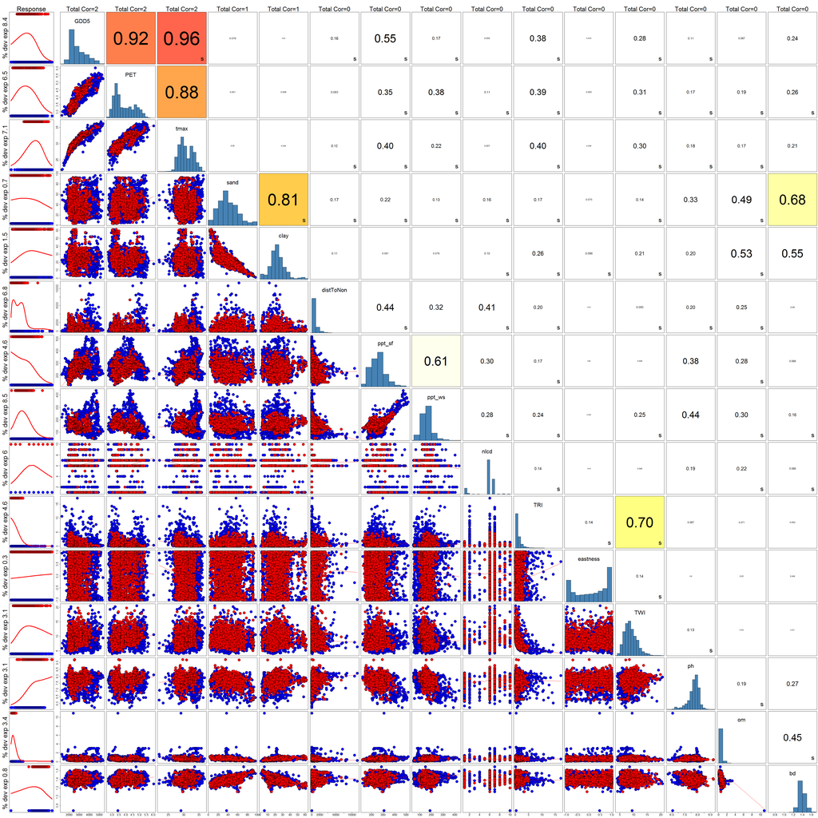

Generated by VisTrails SAHM

## ROC Plots

*Note:* I’ve included the metrics for the “Climate and Topo/Soils” models (i.e., no land-cover) for comparison, but I only ran the cross-validation on the models that included land-cover.

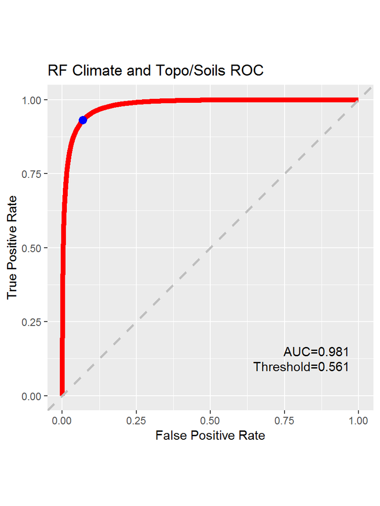

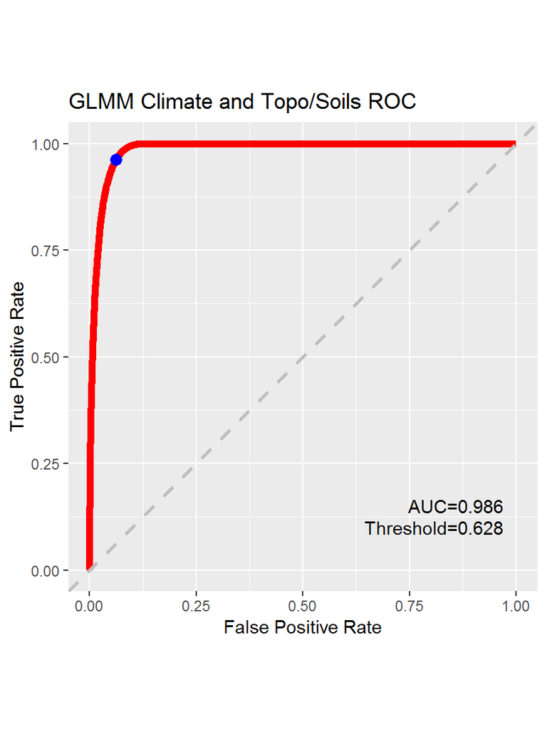

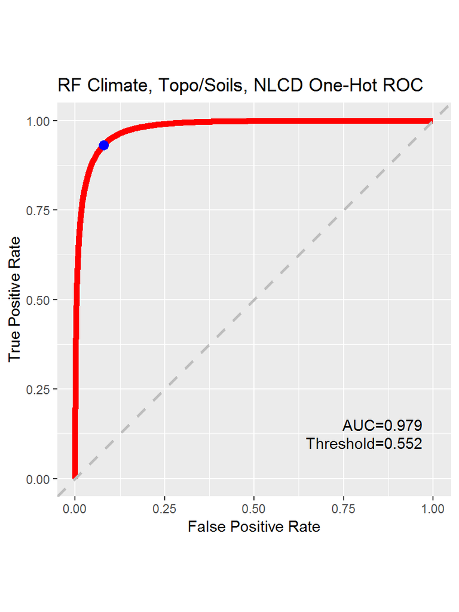

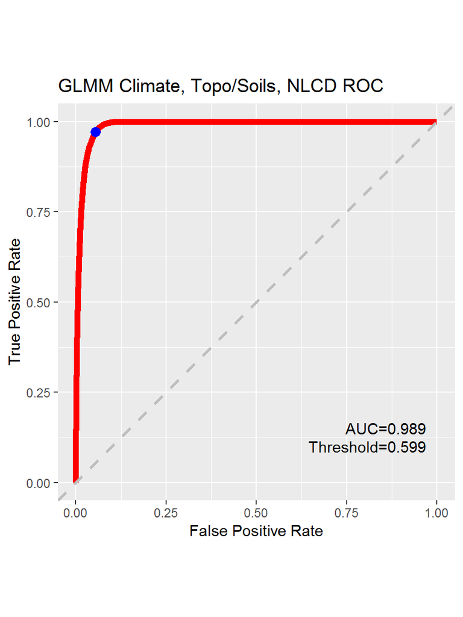

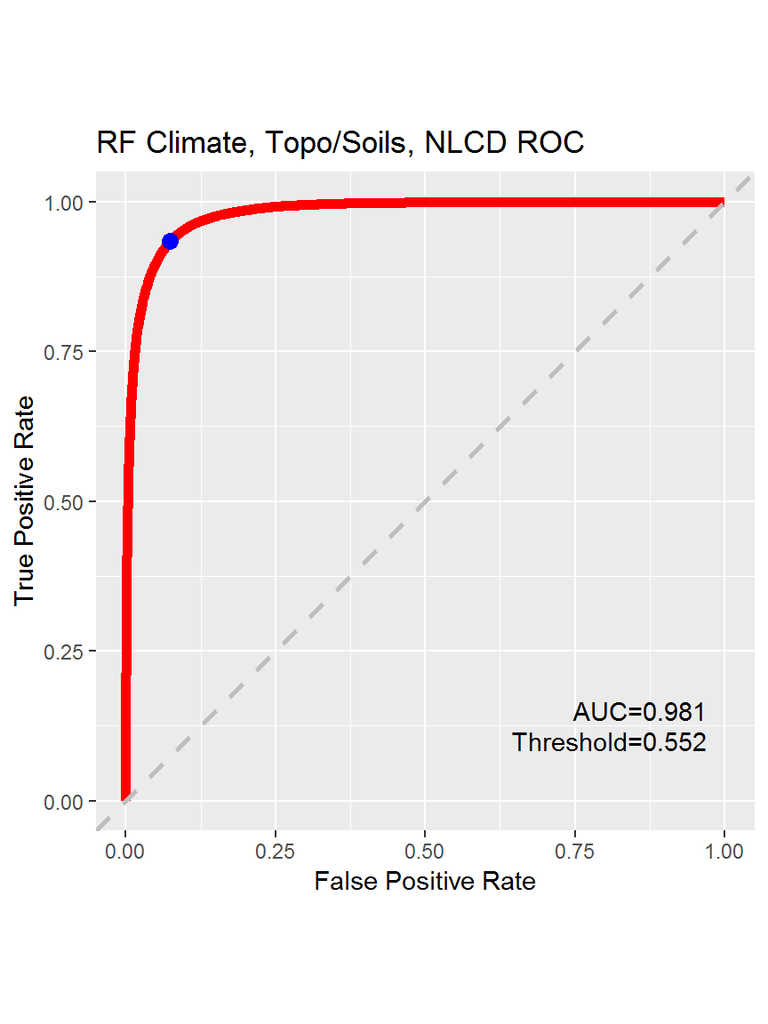

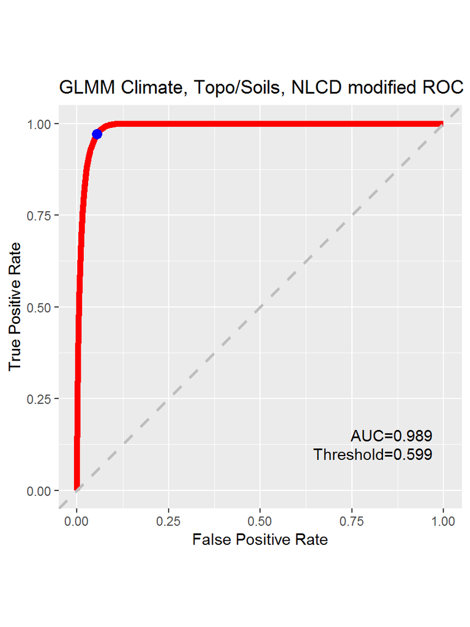

```r
evRF_cd[1]
evGLM_cd[1]

evRF_all1[1]
evGLM_all[1]

evRF_all2[1]
evGLM_all2[1]
## [[1]]
##
## [[1]]
##
## [[1]]
##
## [[1]]
##
## [[1]]
##
## [[1]]
```

## Evaluation Metrics

*Note:* I’ve included the metrics for the “Climate and Topo/Soils” models (i.e., no land-cover) for comparison, but I only ran the cross-validation on the models that included land-cover.

### Metrics for the full model runs

```r
kable(outdf, format = "html", row.names = FALSE, digits = 3) %>%
  kable_styling(bootstrap_options = c("striped", "hover", "condensed", "responsive")) %>%
  column_spec(2:9, color="black") %>% column_spec(1, bold=TRUE)
```

| Model | AUC | TSS | Error_Rate | Kappa | PCC | Sensitivity | Specificity | Threshold |
| --- | --- | --- | --- | --- | --- | --- | --- | --- |
| RF Climate and Topo/Soils | 0.981 | 0.862 | 0.071 | 0.862 | 0.931 | 0.931 | 0.931 | 0.561 |
| GLMM Climate and Topo/Soils | 0.986 | 0.901 | 0.050 | 0.901 | 0.950 | 0.963 | 0.938 | 0.628 |
| RF Climate, Topo/Soils, NLCD One-Hot | 0.979 | 0.852 | 0.075 | 0.852 | 0.926 | 0.932 | 0.921 | 0.552 |
| GLMM Climate, Topo/Soils, NLCD | 0.989 | 0.916 | 0.042 | 0.916 | 0.958 | 0.971 | 0.946 | 0.599 |
| RF Climate, Topo/Soils, NLCD | 0.981 | 0.860 | 0.071 | 0.860 | 0.930 | 0.934 | 0.926 | 0.552 |
| GLMM Climate, Topo/Soils, NLCD modified | 0.989 | 0.916 | 0.042 | 0.916 | 0.958 | 0.971 | 0.946 | 0.599 |

### Cross-fold validation metrics

A k-fold split number was randomly assigned to each Grid_ID. There are 15,185 unique Grid_IDs in the dataset, so each fold contains ~1,518 sampling grid cells. While the technique used selects whole cells (i.e., all the presence/absence points within the cell), it selects them randomly across the region and not stratified geographically. Also note that the number of presence vs. absence points in each fold is *not* equal, but the results were checked and look reasonable.

**Mean of 10 folds:**

```r
# These metrics were previously created in kfold.r
cv_metrics <- read.csv("CrossValidation_metrics.csv")
mnmetrics <- cv_metrics %>% select(-fold) %>%
  group_by(model) %>%
  summarize_all(.funs=mean)

kable(mnmetrics, format = "html", row.names = FALSE, digits = 3) %>%
  kable_styling(bootstrap_options = c("striped", "hover", "condensed", "responsive")) %>%
  column_spec(2:9, color="black") %>% column_spec(1, bold=TRUE)
```

| model | AUC | TSS | err_rate | kappa | PCC | Sensitivity | Specificity | Threshold |
| --- | --- | --- | --- | --- | --- | --- | --- | --- |
| GLMER_alltypes_Feb25 | 0.770 | 0.448 | 0.276 | 0.447 | 0.724 | 0.756 | 0.691 | 0.022 |
| GLMER_alltypes_Mar02 | 0.826 | 0.514 | 0.243 | 0.513 | 0.757 | 0.771 | 0.742 | 0.029 |
| RF_alltypes_Mar02 | 0.903 | 0.656 | 0.172 | 0.655 | 0.827 | 0.846 | 0.810 | 0.329 |
| RF_alltypes_onehot_Feb25 | 0.901 | 0.652 | 0.174 | 0.650 | 0.826 | 0.836 | 0.816 | 0.348 |

*Note:* The model names are getting long and confusing. Here’s how they map out with the above table;

- GLMER_alltypes_Feb25 = GLMM Climate, Topo/Soils, NLCD
- GLMER_alltypes_Mar02 = GLMM Climate, Topo/Soils, NLCD formula modified
- RF_alltypes_onehot_Feb25 = RF Climate, Topo/Soils, NLCD One-Hot
- RF_alltypes_Mar02 = RF Climate, Topo/Soils, NLCD (as factor)

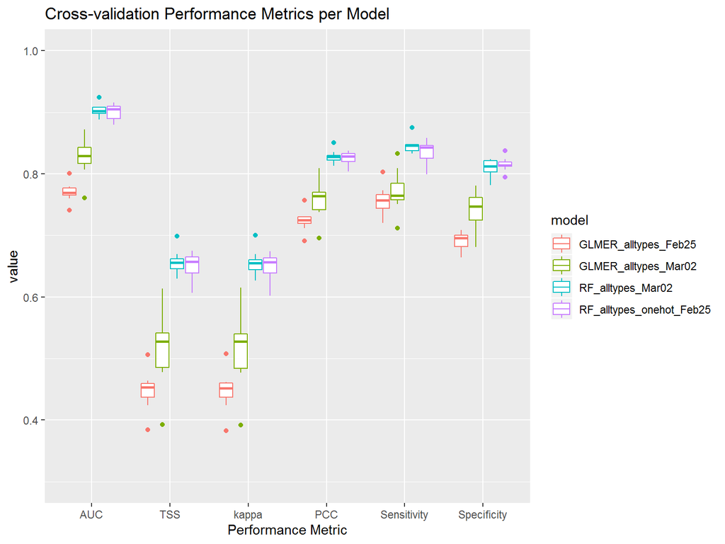

```r
cv <- as.data.table(cv_metrics)
tograph <- melt(cv, id.vars = c("model", "fold"), measure.vars = c(3, 4, 6:9), variable.name = "metric")
qplot(factor(metric), value, data=tograph, geom="boxplot", color=model, ylim = c(0.3,1),
      xlab = "Performance Metric", main = "Cross-validation Performance Metrics per Model")
```

## Variable Importance

*Note:* I’ve included the metrics for the “Climate and Topo/Soils” models (i.e., no land-cover) for comparison, but I only ran the cross-validation on the models that included land-cover.

### 1) Climate + Topo/Soils + Interactions (for GLMM anyway)

#### Random Forest

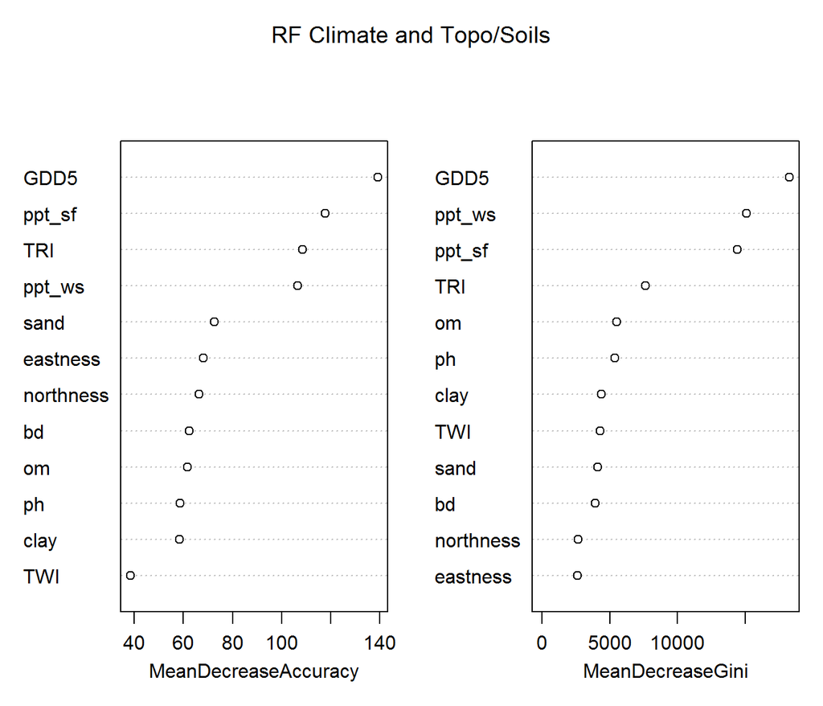

```r
varImpPlot(RF_cd, main = evRF_cd[[2]][1])
```

```r
ptab_rf <- table(RF_cd$predicted, RF_cd$y)

print("Confusion Matrix")
getConfusionMatrix(ptab_rf)
```

```
## [1] "Confusion Matrix"
##       0     1 class.error
## 0 80152  4379  0.05180348
## 1  8150 83923  0.08851672
```

#### GLMM

```r
summary(GLM_cd)

print("Confusion Matrix")
evGLM_cd[3]
```

```
## Generalized linear mixed model fit by maximum likelihood (Adaptive
##   Gauss-Hermite Quadrature, nAGQ = 0) [glmerMod]
##  Family: binomial  ( logit )
## Formula: response ~ 1 + bd + clay + eastness + GDD5 + northness + om +
##     ph + ppt_sf + ppt_ws + sand + TRI + TWI + (1 | Grid_ID) +
##     TWI:clay + GDD5:clay + ppt_sf:clay + ppt_ws:clay
##    Data: indata
## Control: glmerControl(optimizer = "bobyqa")
##
##      AIC      BIC   logLik deviance df.resid
##  66184.9  66366.4 -33074.5  66148.9   176586
##
## Scaled residuals:
##      Min       1Q   Median       3Q      Max
## -28.3084  -0.0734   0.0037   0.1841  20.2573
##
## Random effects:
##  Groups  Name        Variance Std.Dev.
##  Grid_ID (Intercept) 26.41    5.139
## Number of obs: 176604, groups:  Grid_ID, 15185
##
## Fixed effects:
##               Estimate Std. Error z value Pr(>|z|)
## (Intercept)   -4.42541    0.61844  -7.156 8.32e-13 ***
## bd             0.78301    0.45448   1.723  0.08491 .
## clay           6.43144    0.99064   6.492 8.46e-11 ***
## eastness      -0.09378    0.01936  -4.844 1.27e-06 ***
## GDD5          -6.44224    0.85226  -7.559 4.06e-14 ***
## northness     -0.11964    0.02041  -5.862 4.58e-09 ***
## om            -0.48712    4.96346  -0.098  0.92182
## ph             2.61179    0.31284   8.349  < 2e-16 ***
## ppt_sf         3.95926    1.38437   2.860  0.00424 **
## ppt_ws        -1.04489    2.39416  -0.436  0.66252
## sand          -0.12752    0.22154  -0.576  0.56489
## TRI         -134.94035    3.29358 -40.971  < 2e-16 ***
## TWI           -0.99953    0.45298  -2.207  0.02735 *
## clay:TWI      -2.41333    1.24433  -1.939  0.05244 .
## clay:GDD5      5.21343    1.95506   2.667  0.00766 **
## clay:ppt_sf  -22.05023    2.84943  -7.738 1.01e-14 ***
## clay:ppt_ws   13.88650    5.14127   2.701  0.00691 **
## ---
## Signif. codes:  0 '***' 0.001 '**' 0.01 '*' 0.05 '.' 0.1 ' ' 1
## [1] "Confusion Matrix"
## [[1]]
##          observed
## predicted     1     0
##         1 84996  5456
##         0  3306 82846
```

### 2) Climate + Topo/Soils + Land Use + Interactions

#### Random Forest with One-Hot NLCD

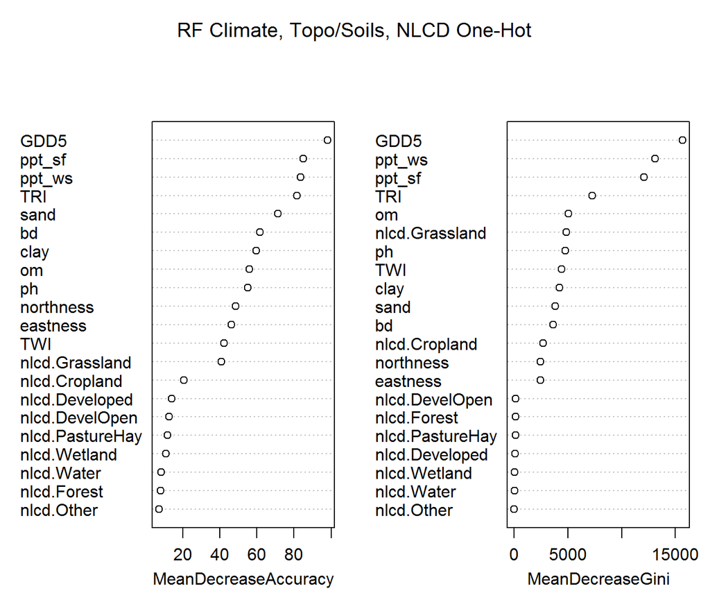

```r
varImpPlot(RF_all1, main = evRF_all1[[2]][1])
```

```r
ptab_rf <- table(RF_all1$predicted, RF_all1$y)

print("Confusion Matrix")
getConfusionMatrix(ptab_rf)
```

```
## [1] "Confusion Matrix"
##       0     1 class.error
## 0 79614  4501  0.05351008
## 1  8688 83801  0.09393550
```

#### GLMM with Original Interations

```r
summary(GLM_all)

print("Confusion Matrix")
evGLM_all[3]
```

```
## Generalized linear mixed model fit by maximum likelihood (Adaptive
##   Gauss-Hermite Quadrature, nAGQ = 0) [glmerMod]
##  Family: binomial  ( logit )
## Formula: response ~ 1 + bd + clay + eastness + GDD5 + nlcd.Cropland +
##     nlcd.Developed + nlcd.DevelOpen + nlcd.Forest + nlcd.Grassland +
##     nlcd.Other + nlcd.PastureHay + nlcd.Water + nlcd.Wetland +
##     northness + om + ph + ppt_sf + ppt_ws + sand + TRI + TWI +
##     (1 | Grid_ID) + TWI:clay + GDD5:clay + ppt_sf:clay + ppt_ws:clay
##    Data: indata
## Control: glmerControl(optimizer = "bobyqa")
##
##      AIC      BIC   logLik deviance df.resid
##  60794.0  61066.2 -30370.0  60740.0   176577
##
## Scaled residuals:
##     Min      1Q  Median      3Q     Max
## -53.064  -0.065   0.002   0.159  18.952
##
## Random effects:
##  Groups  Name        Variance Std.Dev.
##  Grid_ID (Intercept) 27.29    5.224
## Number of obs: 176604, groups:  Grid_ID, 15185
##
## Fixed effects:
##                   Estimate Std. Error z value Pr(>|z|)
## (Intercept)       -3.53063    0.64970  -5.434 5.50e-08 ***
## bd                 0.24436    0.47665   0.513 0.608190
## clay               4.14863    1.06227   3.905 9.41e-05 ***
## eastness          -0.05366    0.02052  -2.615 0.008915 **
## GDD5              -5.96587    0.89869  -6.638 3.17e-11 ***
## nlcd.Cropland     -2.73511    0.07491 -36.514  < 2e-16 ***
## nlcd.Developed    -4.03480    0.29618 -13.623  < 2e-16 ***
## nlcd.DevelOpen    -1.06940    0.12515  -8.545  < 2e-16 ***
## nlcd.Forest       -2.57600    0.25943  -9.929  < 2e-16 ***
## nlcd.Grassland     0.92939    0.04531  20.510  < 2e-16 ***
## nlcd.Other        -1.14685    0.30670  -3.739 0.000184 ***
## nlcd.PastureHay   -0.93807    0.17373  -5.400 6.68e-08 ***
## nlcd.Water        -2.83792    0.35052  -8.096 5.66e-16 ***
## nlcd.Wetland      -1.79247    0.17886 -10.022  < 2e-16 ***
## northness         -0.07840    0.02163  -3.625 0.000289 ***
## om                10.92003    5.35209   2.040 0.041318 *
## ph                 1.75083    0.32714   5.352 8.70e-08 ***
## ppt_sf             2.78423    1.44372   1.929 0.053791 .
## ppt_ws             0.96472    2.49696   0.386 0.699232
## sand              -0.65997    0.23357  -2.826 0.004720 **
## TRI             -152.07604    3.58819 -42.382  < 2e-16 ***
## TWI               -0.82404    0.47880  -1.721 0.085242 .
## clay:TWI          -0.79552    1.31264  -0.606 0.544484
## clay:GDD5          5.29425    2.07476   2.552 0.010719 *
## clay:ppt_sf      -14.48999    2.99573  -4.837 1.32e-06 ***
## clay:ppt_ws        5.75791    5.45435   1.056 0.291126
## ---
## Signif. codes:  0 '***' 0.001 '**' 0.01 '*' 0.05 '.' 0.1 ' ' 1
## [1] "Confusion Matrix"
## [[1]]
##          observed
## predicted     1     0
##         1 85708  4789
##         0  2594 83513
```

### 3) Tweaks to the above models

#### Random Forest with NLCD as factor, not one-hot

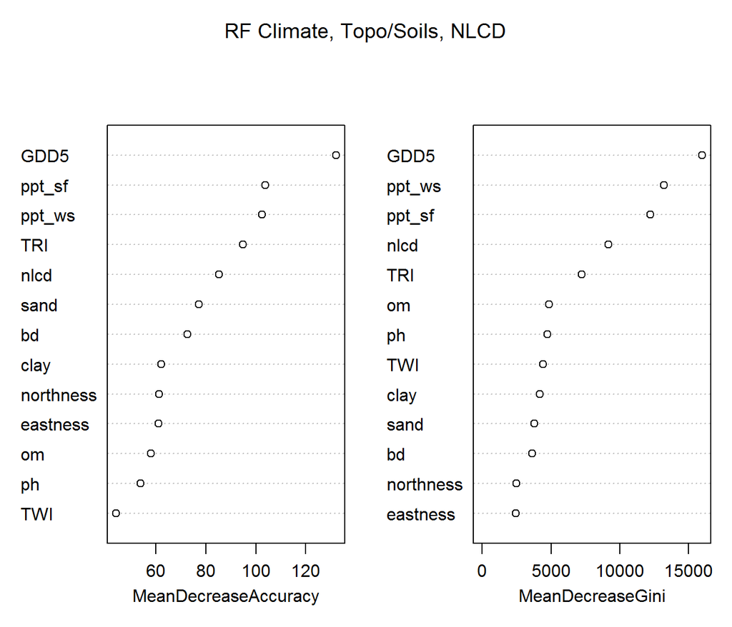

```r
varImpPlot(RF_all2, main = evRF_all2[[2]][1])
```

```r
ptab_rf <- table(RF_all2$predicted, RF_all2$y)

print("Confusion Matrix")
getConfusionMatrix(ptab_rf)
```

```
## [1] "Confusion Matrix"
##       0     1 class.error
## 0 80108  4403  0.05209973
## 1  8194 83899  0.08897527
```

```r
summary(GLM_all2)

print("Confusion Matrix")
evGLM_all2[3]
```

```
## Generalized linear mixed model fit by maximum likelihood (Adaptive
##   Gauss-Hermite Quadrature, nAGQ = 0) [glmerMod]
##  Family: binomial  ( logit )
## Formula: response ~ 1 + bd + clay + eastness + GDD5 + nlcd.Cropland +
##     nlcd.Developed + nlcd.DevelOpen + nlcd.Forest + nlcd.Grassland +
##     nlcd.Other + nlcd.PastureHay + nlcd.Water + nlcd.Wetland +
##     northness + om + ph + ppt_sf + ppt_ws + sand + TRI + TWI +
##     (1 | Grid_ID) + TWI:clay + GDD5:clay + ppt_sf:clay + ppt_ws:clay
##    Data: indata
## Control: glmerControl(optimizer = "bobyqa")
##
##      AIC      BIC   logLik deviance df.resid
##  60794.0  61066.2 -30370.0  60740.0   176577
##
## Scaled residuals:
##     Min      1Q  Median      3Q     Max
## -53.064  -0.065   0.002   0.159  18.952
##
## Random effects:
##  Groups  Name        Variance Std.Dev.
##  Grid_ID (Intercept) 27.29    5.224
## Number of obs: 176604, groups:  Grid_ID, 15185
##
## Fixed effects:
##                   Estimate Std. Error z value Pr(>|z|)
## (Intercept)       -3.53063    0.64970  -5.434 5.50e-08 ***
## bd                 0.24436    0.47665   0.513 0.608190
## clay               4.14863    1.06227   3.905 9.41e-05 ***
## eastness          -0.05366    0.02052  -2.615 0.008915 **
## GDD5              -5.96587    0.89869  -6.638 3.17e-11 ***
## nlcd.Cropland     -2.73511    0.07491 -36.514  < 2e-16 ***
## nlcd.Developed    -4.03480    0.29618 -13.623  < 2e-16 ***
## nlcd.DevelOpen    -1.06940    0.12515  -8.545  < 2e-16 ***
## nlcd.Forest       -2.57600    0.25943  -9.929  < 2e-16 ***
## nlcd.Grassland     0.92939    0.04531  20.510  < 2e-16 ***
## nlcd.Other        -1.14685    0.30670  -3.739 0.000184 ***
## nlcd.PastureHay   -0.93807    0.17373  -5.400 6.68e-08 ***
## nlcd.Water        -2.83792    0.35052  -8.096 5.66e-16 ***
## nlcd.Wetland      -1.79247    0.17886 -10.022  < 2e-16 ***
## northness         -0.07840    0.02163  -3.625 0.000289 ***
## om                10.92003    5.35209   2.040 0.041318 *
## ph                 1.75083    0.32714   5.352 8.70e-08 ***
## ppt_sf             2.78423    1.44372   1.929 0.053791 .
## ppt_ws             0.96472    2.49696   0.386 0.699232
## sand              -0.65997    0.23357  -2.826 0.004720 **
## TRI             -152.07604    3.58819 -42.382  < 2e-16 ***
## TWI               -0.82404    0.47880  -1.721 0.085242 .
## clay:TWI          -0.79552    1.31264  -0.606 0.544484
## clay:GDD5          5.29425    2.07476   2.552 0.010719 *
## clay:ppt_sf      -14.48999    2.99573  -4.837 1.32e-06 ***
## clay:ppt_ws        5.75791    5.45435   1.056 0.291126
## ---
## Signif. codes:  0 '***' 0.001 '**' 0.01 '*' 0.05 '.' 0.1 ' ' 1
## [1] "Confusion Matrix"
## [[1]]
##          observed
## predicted     1     0
##         1 85708  4789
##         0  2594 83513
```